# MDS_HW5

## HW3

#### 第一題 Nov. 12 資料科學應用案例演講

(a) (5%) 該演講對您來說印象深刻的主題為何?為什麼?請摘要此深刻的主題。其對您來 說帶來的啟發為何?

- 我認為讓我印象深刻的主題是「智慧工廠」這個主題。
- 摘要：
  - 從傳統工廠走到智慧工廠最主要的改革有三：人、資訊與建立。
  - 人又可以分為：作業人的數量以及自動化造成的差異。而資訊則是資訊的數位化。最後則是建立。建立視覺機器人的團隊、資料分析團隊、智能設備、系統暨資料視覺化。
- 啟發 ：我認為最主要的啟發是在智慧工廠的cycle，因為這個完全呼應了老師上課所說的資料分析的架構。我一直把資料分析的架構想成是一個在某架構中的一個環節，卻萬萬沒想到他可以自成一個大架構。而在智慧工廠裡面，智慧製造也是扮演極其重要的角色。之前一直以為智慧製造就是產線自動化，或是訂貨自動化，透過演講才知道原來根本不是想像中這麼簡單。智慧製造是在敘述著一種基礎，主要用在機台設備、生產製造、、維護人力這三個方向，並在最終達到財務上的成長。

(b) (5%) 該演講是否有翻轉/顛覆您對過去製造業的認知?如果有，什麼認知有了改變?如 果無，什麼樣的認知跟您過去的既定印象一樣，是否有任何建議或可改善之處?

- 有，因為對於製造業都還停留在家庭代工那時候的印象。所以透過演講者的描述與照片中，得知道原來製造已經這麼先進感到嘖嘖稱奇。我覺得最衝擊的就是關於機械的保養。可能是舊有的知識還停留在初會的折舊當中，因為針對設備的保養還停留在折舊，應該就是所謂的時間性保養。殊不知透過數據的蒐集，不在只針對成品的良率預測，更多的是機器的使用年效與狀況，在即時的給予資源與更新，不僅能降低舊換新的超高成本，延長使用年限，亦可以降低製成品的良率。這樣一石二鳥的利用，不僅僅將投入的成本發揮到最高效，同時亦能達到上面智慧製造最後的目的地。我想這就是科技的厲害之處，不單單只解決了一個問題，若是將它應用在諸多層面，通常就能發揮更大的效益。不過前提是能準確的預估以及「大幅」的提升良率才可以，所以雖然設備與製程讓人為之一亮，實際結果還是要有巨大的轉折才是真正的「智慧製造」。

(c) (5%) 該演講讓您瞭解到製造業應用數據科學方法的困難與挑戰在於何處?為什麼? 如何建議或解決?

- 我認為最大的困難之處還是在於資料的蒐集，講者有提到感應器的放置位置影響到資料蒐集的準確或是甚至是蒐集錯誤。在來是資料失真的問題，亦或是根本沒有蒐集到。
- 講者有提到虛擬測量，我在想是否可以利用對抗生成數據的方式，蒐集一小段數據，或是幾組機台的數據之後，讓機器學習自行生成數據，除了可以減少放置奇怪位置所導致的資訊勘誤，也可以減少感測器的設置。然而，我想，在製造現場最珍貴的就是那些「失真」到數據，異於常理的資料才更顯得可貴。所以我的想法是或許可以採取混合式的方式，例如將感測器減少一半，或是每天蒐集不固定區域的數據，然後剩下的仍透過機器學習來模擬，除了增加資料的擬真性，也可以達到前面遇到的困難。

(d) (5%) 演講內容中，是否有任何疑點?或想問講者的問題為何?

- 講者您好，首先先謝謝您帶來精彩的演講。想請問智慧工廠或是智慧製成的成功率大約是多少？跟業界在做數位轉型一樣困難，還是其實只要投入資本就可以獲得一定的效益？ 謝謝

(e) (5%) 在演講內容中，是否有任何想給予建議的地方?例如問題切入點、問題本質、方 法調整、驗證的省思等。

- 無，我覺得帶給我不同角度的演講很好。而且可能對於製造業也不是那麼了解，所以我覺得講者的切入點挺好的，而且最後還有友達的例子，讓我陳舊的知識庫得以升級，所以我覺得挺好的，謝謝講者。

#### 第二題 Decision Tree Algorithms

```python
#### imports
from sklearn.model_selection import train_test_split
import pandas as pd
import numpy as np
import seaborn as sns
import matplotlib.pyplot as plt
from matplotlib import pyplot
from sklearn.model_selection import cross_val_score
from sklearn.tree import DecisionTreeClassifier
from sklearn.metrics import f1_score
```

```python
# Code to read csv file into Colaboratory:
!pip install -U -q PyDrive
from pydrive.auth import GoogleAuth
from pydrive.drive import GoogleDrive
from google.colab import auth
from oauth2client.client import GoogleCredentials
# Authenticate and create the PyDrive client.
auth.authenticate_user()
gauth = GoogleAuth()
gauth.credentials = GoogleCredentials.get_application_default()
drive = GoogleDrive(gauth)
```

```python
id= '12pb7T3OzLnWTyPGkTsL5Z5MueAqdLq3f'
downloaded = drive.CreateFile({'id':id})
downloaded.GetContentFile('faults.csv')
steelplate_df = pd.read_csv('faults.csv')
```

##### (a) (5%) Construct a data science framework and show the data summary

```python
steelplate_df.describe()
```

|  | X_Minimum | X_Maximum | Y_Minimum | Y_Maximum | Pixels_Areas | X_Perimeter | Y_Perimeter | Sum_of_Luminosity | Minimum_of_Luminosity | Maximum_of_Luminosity | Length_of_Conveyer | TypeOfSteel_A300 | TypeOfSteel_A400 | Steel_Plate_Thickness | Edges_Index | Empty_Index | Square_Index | Outside_X_Index | Edges_X_Index | Edges_Y_Index | Outside_Global_Index | LogOfAreas | Log_X_Index | Log_Y_Index | Orientation_Index | Luminosity_Index | SigmoidOfAreas | Pastry | Z_Scratch | … |
| --- | --- | --- | --- | --- | --- | --- | --- | --- | --- | --- | --- | --- | --- | --- | --- | --- | --- | --- | --- | --- | --- | --- | --- | --- | --- | --- | --- | --- | --- | --- |
| count | 1941.000000 | 1941.000000 | 1.941000e+03 | 1.941000e+03 | 1941.000000 | 1941.000000 | 1941.000000 | 1.941000e+03 | 1941.000000 | 1941.000000 | 1941.000000 | 1941.000000 | 1941.000000 | 1941.000000 | 1941.000000 | 1941.000000 | 1941.000000 | 1941.000000 | 1941.000000 | 1941.000000 | 1941.000000 | 1941.000000 | 1941.000000 | 1941.000000 | 1941.000000 | 1941.000000 | 1941.000000 | 1941.000000 | 1941.000000 | … |
| mean | 571.136012 | 617.964451 | 1.650685e+06 | 1.650739e+06 | 1893.878413 | 111.855229 | 82.965997 | 2.063121e+05 | 84.548686 | 130.193715 | 1459.160227 | 0.400309 | 0.599691 | 78.737764 | 0.331715 | 0.414203 | 0.570767 | 0.033361 | 0.610529 | 0.813472 | 0.575734 | 2.492388 | 1.335686 | 1.403271 | 0.083288 | -0.131305 | 0.585420 | 0.081401 | 0.097888 | … |
| std | 520.690671 | 497.627410 | 1.774578e+06 | 1.774590e+06 | 5168.459560 | 301.209187 | 426.482879 | 5.122936e+05 | 32.134276 | 18.690992 | 144.577823 | 0.490087 | 0.490087 | 55.086032 | 0.299712 | 0.137261 | 0.271058 | 0.058961 | 0.243277 | 0.234274 | 0.482352 | 0.788930 | 0.481612 | 0.454345 | 0.500868 | 0.148767 | 0.339452 | 0.273521 | 0.297239 | … |
| min | 0.000000 | 4.000000 | 6.712000e+03 | 6.724000e+03 | 2.000000 | 2.000000 | 1.000000 | 2.500000e+02 | 0.000000 | 37.000000 | 1227.000000 | 0.000000 | 0.000000 | 40.000000 | 0.000000 | 0.000000 | 0.008300 | 0.001500 | 0.014400 | 0.048400 | 0.000000 | 0.301000 | 0.301000 | 0.000000 | -0.991000 | -0.998900 | 0.119000 | 0.000000 | 0.000000 | … |
| 25% | 51.000000 | 192.000000 | 4.712530e+05 | 4.712810e+05 | 84.000000 | 15.000000 | 13.000000 | 9.522000e+03 | 63.000000 | 124.000000 | 1358.000000 | 0.000000 | 0.000000 | 40.000000 | 0.060400 | 0.315800 | 0.361300 | 0.006600 | 0.411800 | 0.596800 | 0.000000 | 1.924300 | 1.000000 | 1.079200 | -0.333300 | -0.195000 | 0.248200 | 0.000000 | 0.000000 | … |
| 50% | 435.000000 | 467.000000 | 1.204128e+06 | 1.204136e+06 | 174.000000 | 26.000000 | 25.000000 | 1.920200e+04 | 90.000000 | 127.000000 | 1364.000000 | 0.000000 | 1.000000 | 70.000000 | 0.227300 | 0.412100 | 0.555600 | 0.010100 | 0.636400 | 0.947400 | 1.000000 | 2.240600 | 1.176100 | 1.322200 | 0.095200 | -0.133000 | 0.506300 | 0.000000 | 0.000000 | … |
| 75% | 1053.000000 | 1072.000000 | 2.183073e+06 | 2.183084e+06 | 822.000000 | 84.000000 | 83.000000 | 8.301100e+04 | 106.000000 | 140.000000 | 1650.000000 | 1.000000 | 1.000000 | 80.000000 | 0.573800 | 0.501600 | 0.818200 | 0.023500 | 0.800000 | 1.000000 | 1.000000 | 2.914900 | 1.518500 | 1.732400 | 0.511600 | -0.066600 | 0.999800 | 0.000000 | 0.000000 | … |
| max | 1705.000000 | 1713.000000 | 1.298766e+07 | 1.298769e+07 | 152655.000000 | 10449.000000 | 18152.000000 | 1.159141e+07 | 203.000000 | 253.000000 | 1794.000000 | 1.000000 | 1.000000 | 300.000000 | 0.995200 | 0.943900 | 1.000000 | 0.875900 | 1.000000 | 1.000000 | 1.000000 | 5.183700 | 3.074100 | 4.258700 | 0.991700 | 0.642100 | 1.000000 | 1.000000 | 1.000000 | … |

##### (b) (5%) What is the problem about the dataset? Any identical column? Any redundant column? Any missing value? How to handle these issues?

- 由下圖可見這個資料集非常的不平衡，而以下方法可以拿來解決此問題
  1. Random Under-Sampling
  2. Random Over-Sampling
  3. Random under-sampling with imblearn
  4. Random over-sampling with imblearn
  5. Under-sampling: Tomek links
  6. Synthetic Minority Oversampling Technique (SMOTE)
  7. NearMiss
  8. Change the performance metric
  9. Penalize Algorithms (Cost-Sensitive Training)
  10. Change the algorithm
- 沒有重複的行,可以使用 drop_duplicated() 來解局問題
- 沒有缺失值 , 可以是用 dropna() 來解決問題

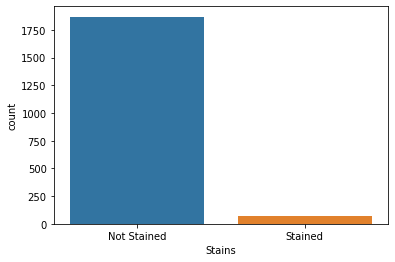

```python
g = sns.countplot(steelplate_df['Stains'])
g.set_xticklabels(['Not Stained','Stained'])
plt.show()
```

```python
steelplate_df.columns.duplicated().any()
```

```
False
```

```python
steelplate_df.isnull().any().any()
```

```
False
```

##### (c) (5%) After data preprocessing, based on the prepared dataset, use the classification and regression tree (CART) to analyze the prepared dataset. Show the classification results by 10-fold cross validation with several metrics (eg. accuracy, area under ROC curve (AUC), and F1-score), and also list the hyperparameters you adjust.

```python
#### 資料切割

x = steelplate_df.drop(columns= ['Stains'])
y = pd.DataFrame( steelplate_df['Stains'])
x_train, x_test, y_train, y_test = train_test_split(x, y, test_size=0.2, random_state=42)
```

```python
#### tune hyper-parameters
hyperparameters={"splitter":["best","random"],
            "max_depth" : [1, 2, 3, 4, 5, 6, 7, 8, 9, 10],
           "min_samples_leaf":[1,2,3,4,5,6,7,8,9,10],
           "max_leaf_nodes":[None,10,20,30,40,50,60,70,80,90] }

##### calculating different regression metrics
from sklearn.model_selection import GridSearchCV
tuning_model=GridSearchCV(estimator=DecisionTreeClassifier(),param_grid=hyperparameters,\
                          scoring='neg_mean_squared_error',cv=10,verbose=1)

tuning_model.fit(x,y)
tuning_model.best_params_
```

```
Fitting 10 folds for each of 2000 candidates, totalling 20000 fits
```

```
{'max_depth': 2,
 'max_leaf_nodes': 50,
 'min_samples_leaf': 1,
 'splitter': 'best'}
```

參考資料 ： https://www.kaggle.com/gauravduttakiit/hyperparameter-tuning-in-decision-trees

```python
#### 製作圖型
clf_cv = DecisionTreeClassifier(criterion = "gini",splitter='best', max_depth =2,max_leaf_nodes=None,min_samples_leaf=4)
clf_cv.fit(x_train, y_train)
# 預測結果
y_pred = clf_cv.predict(x_test)
```

```python
#### ROC-AUC curve
from sklearn.metrics import confusion_matrix,classification_report
from sklearn.metrics import roc_curve, auc
from sklearn.metrics import roc_auc_score

predictions = clf_cv.predict_proba(x_test)
fpr, tpr, _ = roc_curve(y_test, predictions[:,1])
roc = auc(fpr, tpr)
acc = clf_cv.score(x_test, y_test)
```

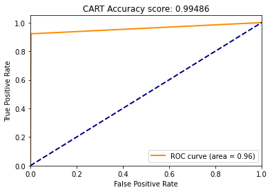

```python
plt.figure()
lw = 2
plt.plot(
    fpr,
    tpr,
    color="darkorange",
    lw=lw,
    label="ROC curve (area = %0.2f)" % roc,
)
plt.plot([0, 1], [0, 1], color="navy", lw=lw, linestyle="--")
plt.xlim([0.0, 1.0])
plt.ylim([0.0, 1.05])
plt.xlabel("False Positive Rate")
plt.ylabel("True Positive Rate")
plt.title("CART Accuracy score: %0.5f" % acc)
plt.legend(loc="lower right")
plt.show()
```

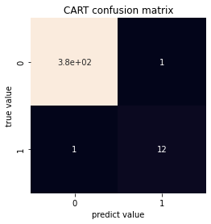

```
F1 score : 0.9230769230769231
```

```python
matric = confusion_matrix(y_test, y_pred)
sns.heatmap(matric,square=True,annot=True,cbar=False)
plt.xlabel("predict value")
plt.ylabel("true value")
plt.title("CART confusion matrix")
plt.show()
print("F1 score :",f1_score(y_test,y_pred ))
```

##### (d) (5%) Suggest a method to address the data imbalance issue. Build a new balanced dataset.

- 使用 Random over-sampling with imblearn 來創造新的資料集

```python
from imblearn.under_sampling import RandomUnderSampler
from collections import Counter
from imblearn.over_sampling import RandomOverSampler

ros = RandomOverSampler(random_state=42)

# fit predictor and target varaible
x_ros, y_ros = ros.fit_resample(x, y)

print('Original dataset shape', Counter(y))
print('Resample dataset shape', Counter(y_ros))
```

```
Original dataset shape Counter({'Stains': 1})
Resample dataset shape Counter({'Stains': 1})
```

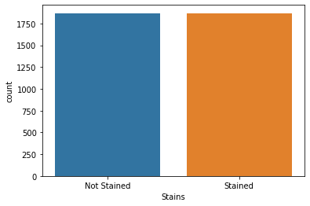

```python
g = sns.countplot(y_ros['Stains'])
g.set_xticklabels(['Not Stained','Stained'])
plt.show()
```

現在分布較為平均了。

##### (e) Based on the balanced dataset, use the classification and regression tree (CART) to analyze the balanced dataset. Show the classification results by 10-fold cross validation with several metrics (eg. accuracy, area under ROC curve (AUC), and F1-score), and also list the hyperparameters you adjust.

```python
#### tune hyper-parameters
hyperparameters={"splitter":["best","random"],
            "max_depth" : [1, 2, 3, 4, 5, 6, 7, 8, 9, 10],
           "min_samples_leaf":[1,2,3,4,5,6,7,8,9,10],
           "max_leaf_nodes":[None,10,20,30,40,50,60,70,80,90] }

##### calculating different regression metrics
from sklearn.model_selection import GridSearchCV
tuning_model=GridSearchCV(estimator=DecisionTreeClassifier(),param_grid=hyperparameters,\
                          scoring='neg_mean_squared_error',cv=10,verbose=1)

tuning_model.fit(x_ros,y_ros)
tuning_model.best_params_
```

```
Fitting 10 folds for each of 2000 candidates, totalling 20000 fits
```

```
{'max_depth': 8,
 'max_leaf_nodes': 90,
 'min_samples_leaf': 3,
 'splitter': 'random'}
```

```python
x_ros_train, x_ros_test, y_ros_train, y_ros_test = train_test_split(x_ros, y_ros, test_size=0.2, random_state=42)
```

```python
#### 製作圖型
bal_clf_cv = DecisionTreeClassifier(criterion = "gini",splitter='random',max_depth=10,max_leaf_nodes=80,min_samples_leaf=3)
bal_clf_cv.fit(x_ros_train, y_ros_train)
# 預測結果
y_ros_pred = clf_cv.predict(x_ros_test)
```

```python
#### ROC AUC Curve
predictions = bal_clf_cv.predict_proba(x_ros_test)
bal_fpr, bal_tpr, _ = roc_curve(y_ros_test, predictions[:,1])
bal_roc = auc(fpr, tpr)
bal_acc = clf_cv.score(x_ros_test, y_ros_test)
```

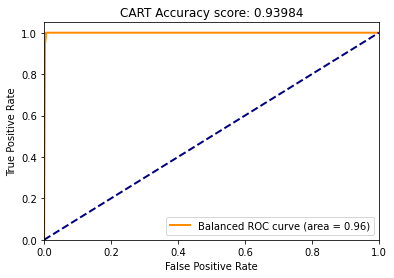

```python
plt.figure()
lw = 2
plt.plot(
    bal_fpr,
    bal_tpr,
    color="darkorange",
    lw=lw,
    label="Balanced ROC curve (area = %0.2f)" % bal_roc,
)
plt.plot([0, 1], [0, 1], color="navy", lw=lw, linestyle="--")
plt.xlim([0.0, 1.0])
plt.ylim([0.0, 1.05])
plt.xlabel("False Positive Rate")
plt.ylabel("True Positive Rate")
plt.title("CART Accuracy score: %0.5f" % bal_acc)
plt.legend(loc="lower right")
plt.show()
```

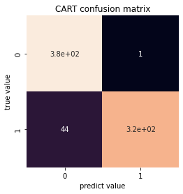

```
F1 score : 0.9350649350649352
```

```python
bal_matric = confusion_matrix(y_ros_test, y_ros_pred)
sns.heatmap(bal_matric,square=True,annot=True,cbar=False)
plt.xlabel("predict value")
plt.ylabel("true value")
plt.title("CART confusion matrix")
plt.show()
print("F1 score :",f1_score(y_ros_test,y_ros_pred ))
```

##### (g) Use “Random Forest” to solve both prepared dataset and balanced dataset, respectively. Give a comparison and provide your insight.

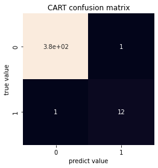

```
F1 score : 0.9230769230769231
```

```python
##### inbalance
from sklearn.ensemble import RandomForestClassifier
from sklearn.datasets import make_classification
rand_imbl_clf = RandomForestClassifier(max_depth=2, random_state=0)
rand_imbl_clf.fit(x_train, y_train)
y_rand_imbl_pred = rand_imbl_clf.predict(x_test)

rand_imbl_matric = confusion_matrix(y_test, y_rand_imbl_pred)
sns.heatmap(rand_imbl_matric,square=True,annot=True,cbar=False)
plt.xlabel("predict value")
plt.ylabel("true value")
plt.title("CART confusion matrix")
plt.show()
print("F1 score :",f1_score(y_test,y_rand_imbl_pred))
```

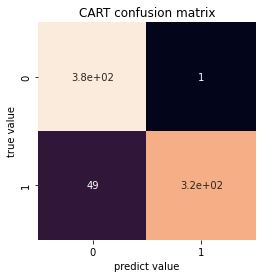

```
F1 score : 0.9273255813953488
```

```python
##### balanced
rand_bal_clf = RandomForestClassifier(max_depth=2, random_state=0)
rand_bal_clf.fit(x_ros_train, y_ros_train)
y_rand_bal_pred = rand_imbl_clf.predict(x_ros_test)

rand_bal_matric = confusion_matrix(y_ros_test, y_rand_bal_pred)
sns.heatmap(rand_bal_matric,square=True,annot=True,cbar=False)
plt.xlabel("predict value")
plt.ylabel("true value")
plt.title("CART confusion matrix")
plt.show()
print("F1 score :",f1_score(y_ros_test,y_rand_bal_pred ))
```

##### (h) Use “Gradient Boosting Decision Tree (GBDT)” to solve both prepared dataset and balanced dataset, respectively. Give a comparison and provide your insight.

```python
#### imbal
from sklearn.ensemble import GradientBoostingClassifier
imbl_GBDT = GradientBoostingClassifier(n_estimators=100, learning_rate=1.0,max_depth=1, random_state=0).fit(x_train, y_train)
imbl_GBDT.score(x_test, y_test)
```

```
0.9948586118251928
```

```python
#### balanced
from sklearn.ensemble import GradientBoostingClassifier
bal_GBDT = GradientBoostingClassifier(n_estimators=100, learning_rate=1.0,max_depth=1, random_state=0).fit(x_ros_train, y_ros_train)
bal_GBDT.score(x_ros_test, y_ros_test)
```

```
1.0
```

#### 第三題 Deep Learning

###### (a) For CNN, try to investigate the effects of changing “PARAMETERS” such as learning rates, momentum, # of hidden/convolutional layers, dropout rate, etc. Show the numerical results and “DIAGRAM” from different perspectives (e.g., accuracy, F1-score, convergence time, error of training data, error of testing data, etc.). Please show all your work in detail, in particular, you “MAY” need to design your experiments with different parameters systematically.

參考資料：

1. [Day 05：Keras 模型、函數及參數使用說明](https://ithelp.ithome.com.tw/articles/10191725)
2. [QC using CNN](https://www.kaggle.com/sonyd4d/qc-using-cnn)
3. [MDS 筆記](https://github.com/PO-LAB/Manufacturing-Data-Science/blob/master/MDS/10.%20Neural%20Network/NN.ipynb)
4. [參數調整](https://machinelearningmastery.com/understand-the-dynamics-of-learning-rate-on-deep-learning-neural-networks/)

```python
import os
import warnings
import tensorflow as tf
import keras
from tensorflow.keras.models import Sequential
from tensorflow.keras.layers import Dense
from tensorflow.keras.optimizers import SGD
from tensorflow.keras.layers import Dropout
from tensorflow.keras.losses import categorical_crossentropy
from tensorflow.keras.utils import to_categorical
from tensorflow.keras.layers import Conv2D, MaxPooling2D
from tensorflow.keras.layers import Dense, Flatten
from sklearn.metrics import accuracy_score
from sklearn.metrics import classification_report
from keras.utils.vis_utils import plot_model
from tensorflow.keras.callbacks import ModelCheckpoint
from tensorflow.keras.optimizers import Adam
```

```python
#### setting environment

from google.colab import drive
drive.mount('/content/drive')

# train_def = "https://drive.google.com/drive/folders/1PT0fVV-JVxT_MnYbFyCioBliXW2-_vRr?usp=sharing"
# train_ok = "https://drive.google.com/drive/folders/1ooBMfoALlxp5trA-_paKxrXn7KrP7Q-j?usp=sharing"
# test_def = "https://drive.google.com/drive/folders/1DTGayHEslqyu7WNZBFxu1uzQ3PnYal7V?usp=sharing"
# test_ok = "https://drive.google.com/drive/folders/1qthnUsDXU-7Ob402qte9Xq8WB8qbngv9?usp=sharing"
```

```python
#### load files
base_dir = '/content/drive/My Drive/MDS/HW3/casting_data'
train_dir = os.path.join(base_dir, 'train')
test_dir = os.path.join(base_dir, 'test')

train_def = os.path.join(train_dir, 'def_front')         # 取得訓練用 def 圖片的路徑
train_ok = os.path.join(train_dir, 'ok_front')           # 取得訓練用 ok 圖片的路徑
test_def = os.path.join(test_dir, 'def_front')           # 取得驗證用 def 圖片的路徑
test_ok = os.path.join(test_dir, 'ok_front')             # 取得驗證用 ok 圖片的路徑
```

###### EDA (Exploratory data analysis)

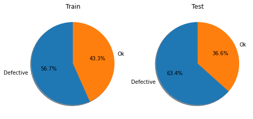

```python
#### number of images
x_train = np.array([len(os.listdir(train_def)),len(os.listdir(train_ok))])
x_test = np.array([len(os.listdir(test_def)),len(os.listdir(test_ok))])
label = ['Defective','Ok']

fig, axes = plt.subplots(1, 2, figsize=(8,4))
axes[0].pie(x_train, labels=label, autopct='%1.1f%%',shadow=True, startangle=90)
axes[1].pie(x_test, labels=label, autopct='%1.1f%%',shadow=True, startangle=90)
axes[0].set_title('Train')
axes[1].set_title('Test')
plt.show()
```

```python
print(' Defective Training Images \t: ' + str(len(os.listdir(train_def))))
print(' Ok Training Images \t\t: ' + str(len(os.listdir(train_ok))))
print()
print(' Defective Testing Images \t: ' + str(len(os.listdir(test_def))))
print(' Ok Testing Images \t\t: ' + str(len(os.listdir(test_ok))))
```

```
 Defective Training Images 	: 3758
 Ok Training Images 		: 2875

 Defective Testing Images 	: 453
 Ok Testing Images 		: 262
```

###### Data Loading and Preprocessing

- 0/1 Normalization
- Grayscale
- input shape resize for CNN (300x300)

```python
from tensorflow.keras.preprocessing.image import ImageDataGenerator

# Using IDG to load images from directory
train_idg = ImageDataGenerator(rescale=1./255, validation_split=0.3) # 30 percent validation split for taining
test_idg = ImageDataGenerator(rescale=1./255)

# Specify parameters/arguments for data generation
img_size = (300, 300)
batch_size = 64

arg_train = {'target_size': img_size,
             'color_mode': 'grayscale',
             'class_mode': 'binary',
             'batch_size': batch_size}
arg_test = {'target_size': img_size,
            'color_mode': 'grayscale',
            'class_mode': 'binary',
            'batch_size': batch_size,
            'shuffle': False}
train = train_idg.flow_from_directory(train_dir, subset='training', **arg_train)
valid = train_idg.flow_from_directory(train_dir, subset='validation', **arg_train)
test  = test_idg.flow_from_directory(test_dir, **arg_test)
```

```
Found 4644 images belonging to 2 classes.
Found 1989 images belonging to 2 classes.
Found 715 images belonging to 2 classes.
```

###### Build Model

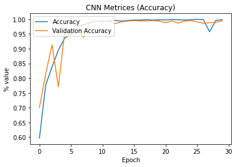

```python
#### tune epoch
cnn = Sequential([
    Conv2D(32, 3, activation='relu', padding='same', strides=2,input_shape=img_size+(1,)),
    MaxPooling2D(pool_size=2, strides=2),
    Conv2D(64, 3, activation='relu', padding='same', strides=2),
    MaxPooling2D(pool_size=2, strides=2),
    Flatten(),
    Dense(128, activation='relu'),
    Dense(1, activation='sigmoid')
])

cnn.compile(optimizer=Adam(learning_rate=0.001),loss='binary_crossentropy',metrics=['accuracy'])
history_e = cnn.fit(train ,validation_data=valid,epochs=30,verbose=0)

#### plot
plt.plot(history_e.history['accuracy'], label='Accuracy')
plt.plot(history_e.history['val_accuracy'], label='Validation Accuracy')
plt.title('CNN Metrices (Accuracy)')
plt.ylabel('% value')
plt.xlabel('Epoch')
plt.legend(loc="upper left")
plt.show()
```

可以發現 epoch 在 **15** 的時候準確率較高。

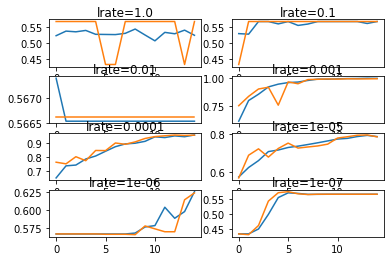

```python
##### tune learning rate

def fit_model(train,valid,lrate):
    # define model
    cnn_ = Sequential([
    #### layer 1
    Conv2D(32, 3, activation='relu', padding='same', strides=2,input_shape=img_size+(1,)),
    MaxPooling2D(pool_size=2, strides=2),

    #### layer 2
    Conv2D(64, 3, activation='relu', padding='same', strides=2),
    MaxPooling2D(pool_size=2, strides=2),

    ##### flatten
    Flatten(),
    Dense(128, activation='relu'),
    Dense(1, activation='sigmoid')
    ])

    #### compile
    cnn_.compile(optimizer=Adam(learning_rate=lrate),loss='binary_crossentropy',metrics=['accuracy'])

    # fit model
    history = cnn_.fit(train ,validation_data=valid,epochs=15,verbose=0)

    # plot learning curves
    plt.plot(history.history['accuracy'], label='Accuracy')
    plt.plot(history.history['val_accuracy'], label='Validation Accuracy')
    pyplot.title('lrate='+str(lrate), pad=-50)



learning_rates = [1E-0, 1E-1, 1E-2, 1E-3, 1E-4, 1E-5, 1E-6, 1E-7]
for i in range(len(learning_rates)):
	# determine the plot number
	plot_no = 420 + (i+1)
	pyplot.subplot(plot_no)
	# fit model and plot learning curves for a learning rate
	fit_model(train,valid, learning_rates[i])
# show learning curves
pyplot.show()
```

可以看見 learning rate 在 0.001,0.0001表現較好。因此我們選擇 0.001作為learning rate

```python
#### tune momentum
```

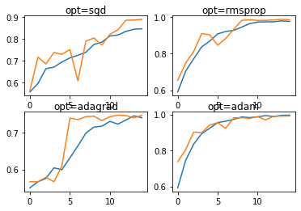

```python
# fit a model and plot learning curve
def fit_model(train,valid, optimizer):
	# define model
	cnn_m = Sequential([
    #### layer 1
    Conv2D(32, 3, activation='relu', padding='same', strides=2,input_shape=img_size+(1,)),
    MaxPooling2D(pool_size=2, strides=2),

    #### layer 2
    Conv2D(64, 3, activation='relu', padding='same', strides=2),
    MaxPooling2D(pool_size=2, strides=2),

    ##### flatten
    Flatten(),
    Dense(128, activation='relu'),
    Dense(1, activation='sigmoid')
    ])

	# compile model
	cnn_m.compile(loss='binary_crossentropy', optimizer=optimizer, metrics=['accuracy'])
	# fit model
	history_m = cnn_m.fit(train, validation_data=valid, epochs=15, verbose=0)
	# plot learning curves
	pyplot.plot(history_m.history['accuracy'], label='train')
	pyplot.plot(history_m.history['val_accuracy'], label='test')
	pyplot.title('opt='+optimizer, pad=-80)




momentums = ['sgd', 'rmsprop', 'adagrad', 'adam']
for i in range(len(momentums)):
	# determine the plot number
	plot_no = 220 + (i+1)
	pyplot.subplot(plot_no)
	# fit model and plot learning curves for an optimizer
	fit_model(train,valid, momentums[i])
# show learning curve
pyplot.show()
```

#### 第四題 Time-Series Prediction

###### 下載資料與 EDA

- 這裡我用的是原油的歷史價格資料 [Crude oil price](https://fred.stlouisfed.org/series/DCOILWTICO)
- 下載的資料一共有兩個欄位，日期與價格
  - 缺失資料先將其踢出，再將字串轉為數字，方便視覺化繪圖

```python
import datetime as dt
import urllib.request, json
import os
import numpy as np
import tensorflow as tf # This code has been tested with TensorFlow 1.6
from sklearn.preprocessing import MinMaxScaler
```

```python
auth.authenticate_user()
gauth = GoogleAuth()
gauth.credentials = GoogleCredentials.get_application_default()
drive = GoogleDrive(gauth)

id= '1jH1NkmOC1R64aZYovhzpW_YBjuA9YLSi'
downloaded = drive.CreateFile({'id':id})
downloaded.GetContentFile('DCOILWTICO.csv')
oil_price_df = pd.read_csv('DCOILWTICO.csv')
```

```python
oil_price_df.head(20)
```

|  | DATE | DCOILWTICO |
| --- | --- | --- |
| 0 | 2000-12-18 | 29.52 |
| 1 | 2000-12-19 | 29.34 |
| 2 | 2000-12-20 | 25.83 |
| 3 | 2000-12-21 | 26.06 |
| 4 | 2000-12-22 | 26.16 |
| 5 | 2000-12-25 | . |
| 6 | 2000-12-26 | 27.00 |
| 7 | 2000-12-27 | 26.55 |
| 8 | 2000-12-28 | 25.82 |
| 9 | 2000-12-29 | 26.72 |
| 10 | 2001-01-01 | . |
| 11 | 2001-01-02 | 27.29 |
| 12 | 2001-01-03 | 27.93 |
| 13 | 2001-01-04 | 27.95 |
| 14 | 2001-01-05 | 28.02 |
| 15 | 2001-01-08 | 27.44 |
| 16 | 2001-01-09 | 27.72 |
| 17 | 2001-01-10 | 29.42 |
| 18 | 2001-01-11 | 29.42 |
| 19 | 2001-01-12 | 30.07 |

```python
drop_list=[]

for i in range(len(oil_price_df)):
  if(oil_price_df.iloc[i,1]=='.'):
    drop_list.append(i)
```

```python
new_oil_df = oil_price_df.drop(drop_list)
```

```python
new_oil_df.reset_index(drop=True, inplace=True)
```

```python
for i in range(len(new_oil_df)):
  new_oil_df.loc[i,'DCOILWTICO'] = float(new_oil_df.loc[i,'DCOILWTICO'] )
```

```
No handles with labels found to put in legend.
```

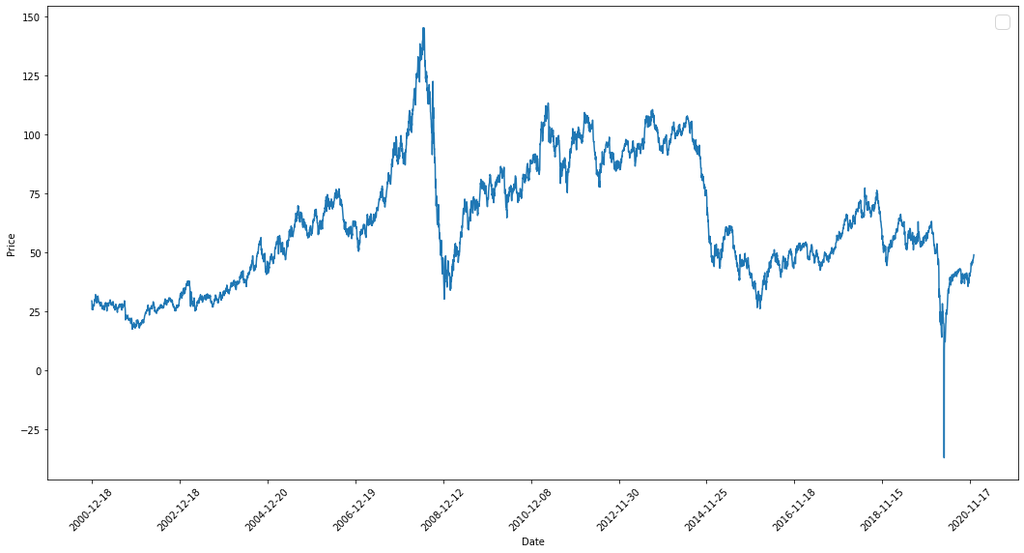

```python
plt.figure(figsize = (18,9))
plt.plot(range(new_oil_df.shape[0]),new_oil_df['DCOILWTICO'])
plt.xticks(range(0,new_oil_df.shape[0],500),new_oil_df['DATE'].loc[::500],rotation=45)
plt.xlabel('Date')
plt.ylabel('Price')
plt.legend(fontsize=18)
plt.show()
```

1. 先將 price 取出來，資料筆數一共有5022筆 將其分成train ,test
2. 將資料正規化
3. 之後測試 standard average 與 exponential moving average 來做模型
4. 繪圖比較兩者預測結果 參考資料 : [LSTM with stock price](https://www.datacamp.com/community/tutorials/lstm-python-stock-market#download)

```python
new_price = new_oil_df.loc[:,'DCOILWTICO'].to_numpy()
n = int(len(new_price)/2)
train_price = new_price[:n]
test_price = new_price[n:]
```

```python
scaler = MinMaxScaler()
train_price = train_price.reshape(-1,1)
test_price = test_price.reshape(-1,1)
```

```python
smoothing_window_size = n
for di in range(0,n,smoothing_window_size):
    scaler.fit(train_price[di:di+smoothing_window_size,:])
    train_price[di:di+smoothing_window_size,:] = scaler.transform(train_price[di:di+smoothing_window_size,:])
```

```python
# Reshape both train and test data
train_price = train_price.reshape(-1)

# Normalize test data
test_price = scaler.transform(test_price).reshape(-1)
```

```python
EMA = 0.0
gamma = 0.1
for ti in range(n):
  EMA = gamma*train_price[ti] + (1-gamma)*EMA
  train_price[ti] = EMA

# Used for visualization and test purposes
all_mid_data = np.concatenate([train_price,test_price],axis=0)
```

```python
#### Standard Average
window_size = 100
N = train_price.size
std_avg_predictions = []
std_avg_x = []
mse_errors = []

for pred_idx in range(window_size,N):

    if pred_idx >= N:
        date = dt.datetime.strptime(k, '%Y-%m-%d').date() + dt.timedelta(days=1)
    else:
        date = new_oil_df.loc[pred_idx,'DATE']

    std_avg_predictions.append(np.mean([train_price[pred_idx-window_size:pred_idx]]))
    mse_errors.append((std_avg_predictions[-1]-train_price[pred_idx])**2)
    std_avg_x.append(date)

print('MSE error for standard averaging: %.5f'%(0.5*np.mean(mse_errors)))
```

```
MSE error for standard averaging: 0.00313
```

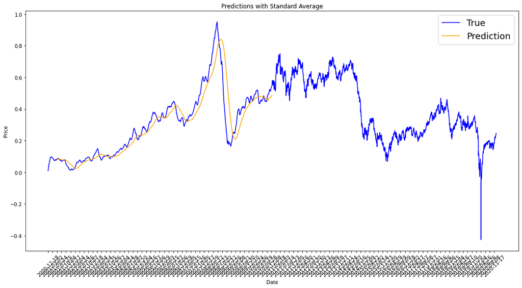

```python
plt.figure(figsize = (18,9))
plt.plot(range(new_oil_df.shape[0]),all_mid_data,color='b',label='True')
plt.plot(range(window_size,N),std_avg_predictions,color='orange',label='Prediction')
plt.xticks(range(0,new_oil_df.shape[0],50),new_oil_df['DATE'].loc[::50],rotation=45)
plt.title('Predictions with Standard Average')
plt.xlabel('Date')
plt.ylabel('Price')
plt.legend(fontsize=18)
plt.show()
```

```python
#### EMA
window_size = 100
N = train_price.size

run_avg_predictions = []
run_avg_x = []

run_mse_errors = []

running_mean = 0.0
run_avg_predictions.append(running_mean)

decay = 0.5

for pred_idx in range(1,N):

    running_mean = running_mean*decay + (1.0-decay)*train_price[pred_idx-1]
    run_avg_predictions.append(running_mean)
    run_mse_errors.append((run_avg_predictions[-1]-train_price[pred_idx])**2)
    run_avg_x.append(date)

print('MSE error for EMA averaging: %.5f'%(0.5*np.mean(run_mse_errors)))
```

```
MSE error for EMA averaging: 0.00001
```

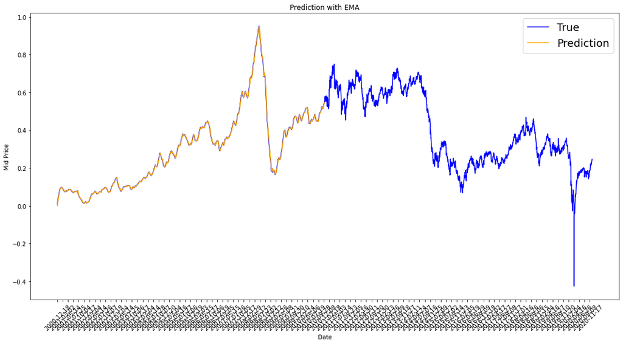

```python
plt.figure(figsize = (18,9))
plt.plot(range(new_oil_df.shape[0]),all_mid_data,color='b',label='True')
plt.plot(range(0,N),run_avg_predictions,color='orange', label='Prediction')
plt.xticks(range(0,new_oil_df.shape[0],50),new_oil_df['DATE'].loc[::50],rotation=45)
plt.title('Prediction with EMA')
plt.xlabel('Date')
plt.ylabel('Mid Price')
plt.legend(fontsize=18)
plt.show()
```

第四題結論  
由上結果可得EMA的效果好很多。而我們在原始圖也可以看出其實原油的價格波動也很大，因此在選用EMA的γ不宜使用太大的間距，選用與股價預測相同的間距，可見得出的結果非常良好。由於只用一部分的資料來做預測。2020歷經covid-19之後，的波動預測或許準確度就會下降。